# Interpolace polynomem

## Polynom

Polynom stupně $n$ je mnohočlen zapsaný ve tvaru:
$$p(x)=a_n x^n + a_{n-1} x^{n-1} +...+a_2x^2 + a_1x + a_0$$
kde $x$ je proměnná a čísla $a_i$ jsou koeficienty polynomu $(a_n \neq 0).$ Koeficienty polynomu jsou zpravidla celá nebo reálná čísla. Stupněm polynomu $p(x)$ rozumíme nejvyšší exponent proměnné $x$ s nenulovým koeficientem. U následujících interpolačních metod platí, že pokud známe $n$ bodů, z výpočtu dostaneme interpolační polynom stupně $n-1$. Takže pokud známe 2 body provádíme interpolaci přímkou, pokud známe body 3 interpolujeme parabolou a tak dále.

## Interpolace

Interpolaci používáme pokud máme nějakou funkci zadanou určitými body a chceme zjistit jak by se tato funkce mezi těmito body chovala. Např. pokud máme funkci $f(x)$ a známe její hodnotu v bodech $f(x_0), f(x_1),..f(x_n)$ interpolací nalezneme funkční hodnoty $f(x)$, pokud platí, že $x_0 < x < x_n$. Existuje několik metod pro výpočet interpolačních polynomů, které si dále popíšeme. Cílem je aby tento polynom napodoboval původní funkci. Obecně platí, že pokud dosadíme dostatek bodů do výpočtu, získáme přesnější interpolaci, jak je předvedeno dále na grafech s $n$ známými body.

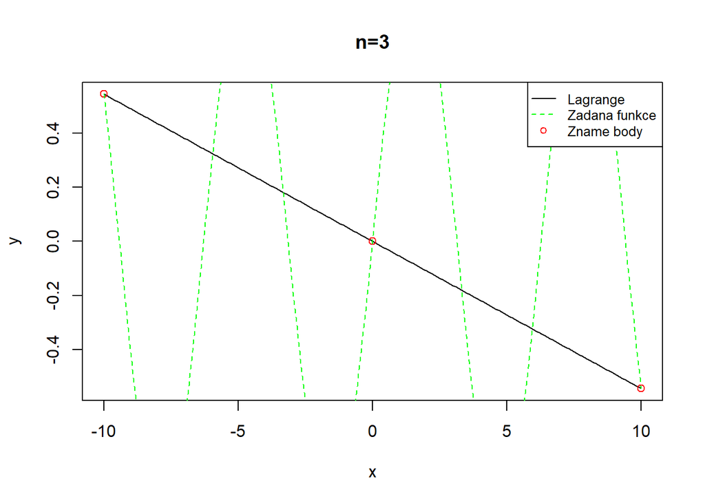

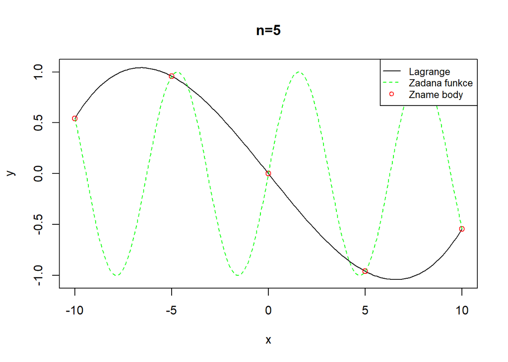

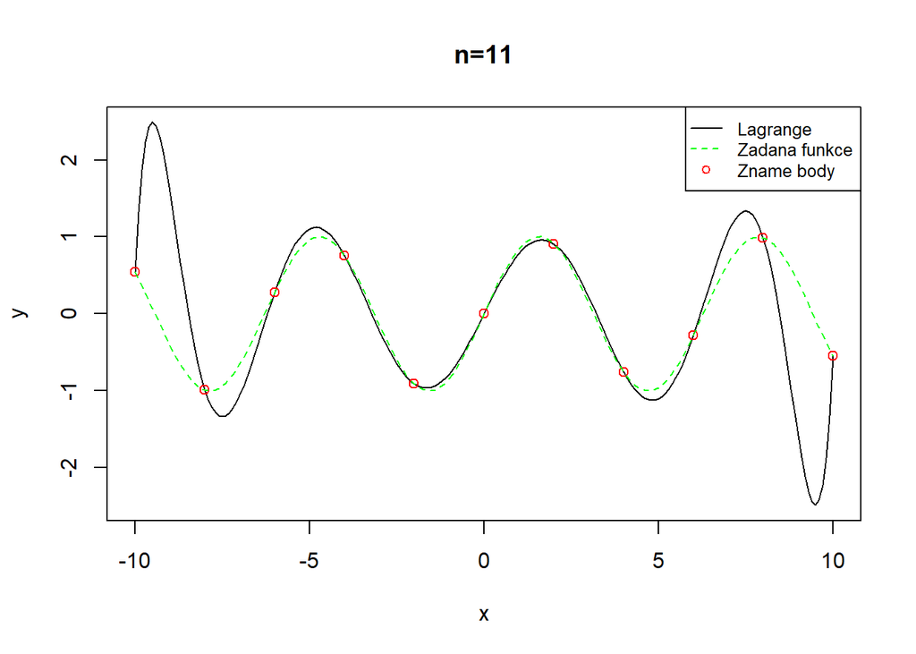

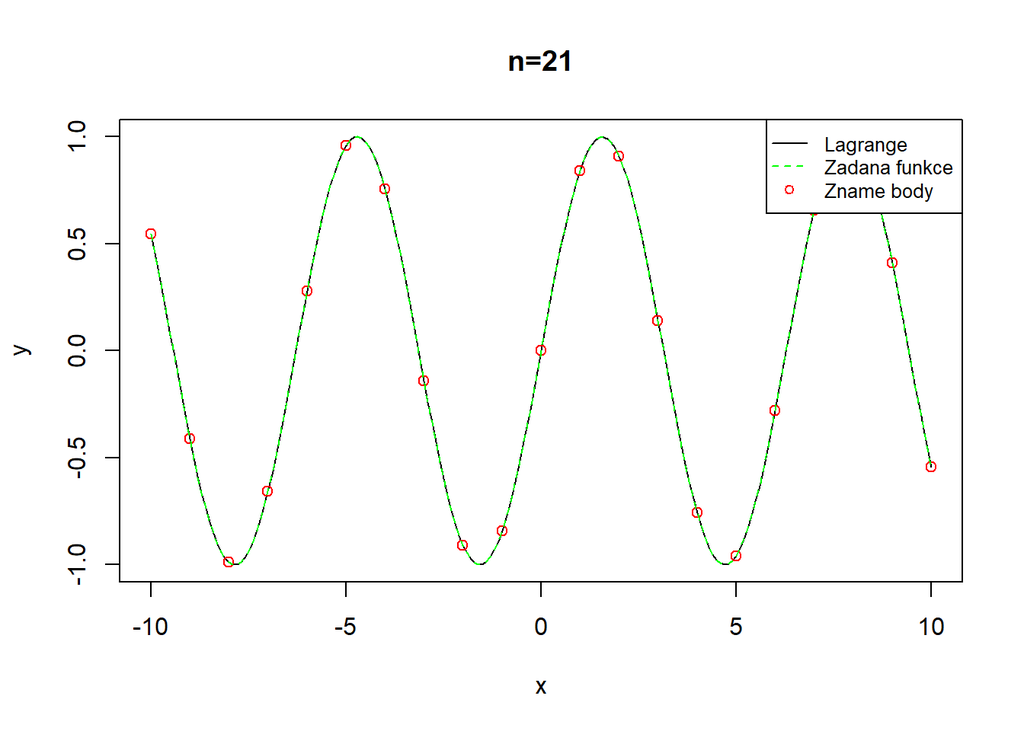

# Vandermondova matice

Vandermodova matice je matice kde každý řádek tvoří geometrickou posloupnost.

$$V=
\begin{bmatrix}
1 & x_1 & x_1^2 & ... & x_1^{n-1}\\
1 & x_2 & x_2^2 & ... & x_2^{n-1}\\
1 & x_3 & x_3^2 & ... & x_3^{n-1}\\
\vdots & \vdots & \vdots & & \vdots\\
1 & x_m & x_m^2 & ... & x_m^{n-1}
\end{bmatrix}$$

takže platí

$$V_{ij}=x_i^{j-1}$$

Vandermodovo matici můžeme využit k získání interpolačního polynomu. Ze souřadnic osy x známých bodů sestavíme Vandermondovo matici a tu pak položíme rovnu souřadnicím osy y těchto bodů. Tímto procesem získáme funkci, která musí procházet zadanými body. Výsledkem jsou koeficienty interpolačního polynomu. Pro počítání a dosazování za $x$ v interpolačním polynomu můžeme použít Hornerovo schéma, pro jednodužší a rychlejší výpočet. Stručně řečeno se jedná o opakované vytknutí neznámé.

$$\begin{bmatrix}
1 & x_1 & x_1^2 & ... & x_1^{n-1}\\
1 & x_2 & x_2^2 & ... & x_2^{n-1}\\
1 & x_3 & x_3^2 & ... & x_3^{n-1}\\
\vdots & \vdots & \vdots & & \vdots\\
1 & x_m & x_m^2 & ... & x_m^{n-1}
\end{bmatrix}
\begin{bmatrix}
a_1\\a_2\\a_3\\\vdots\\a_m
\end{bmatrix}=
\begin{bmatrix}
y_1\\y_2\\y_3\\\vdots\\y_m
\end{bmatrix}$$

### Algoritmus výčtu Vandermondovo matice:

```r
vandermonde.matrix <- function( alpha, n )
{
  # Tato funkce vrací m x n matici mocnin vektoru alfa
  #
  # alpha = m dimenze vektor
  # n = stupen polynomu

  if ( !is.vector( alpha ) )
    stop( "parametr alpha není vektor" )
  if ( !is.numeric( alpha ) )
    stop( "parametr n není číselný vektor" )
  m <- length( alpha )
  V <- matrix( 0, nrow=m, ncol=n )
  V[,1] <- rep( 1, m ) #prvni sloupec jsou vzdy jednicky
  j <- 2
  while ( j <= n ) {
    x <- alpha ^ ( j - 1 )   #umocnim podle toho v jakem jsem sloupci
    V[,j] <- x
    j <- j + 1     #zvetseni mocniny pro dalsi sloupec
  }
  return( V )
}
```

### Algoritmus hornerova schématu

```r
horner<-function(x,a) #x- funkcni hodnota v danych bodech, a- poly. fce ve tvaru a+bx+cx^2... (koeficienty)
{

  n<-length(a)   #n= stupen polynomu (3=x^2)
  res<-a[n]      #do res ulozim nejvyssi clen
  if(n==1)       #kdyz je polynom stupne 0, neni co pocitat
    return (res)
  for(i in (n-1):1)
  {
    res<-res*x+a[i]    #algoritmus pocitani zavorek,  x(x(d+c)+b)+a
    #n uz v res je. Vzdy nasobim s x, a zacinam s pricitanim n-1..n=1
  }

  return (res)
}
```

Pro příklad, pokud budeme mít body se souřadnicemi $[-2;4], [-1;1], [0;0], [1,1]$ a $[2;4]$ (body funkce $x^2$), Vandermondtova matice bude vypadat takto:

$$\begin{bmatrix}1&-2&4&-8&16 \\1&-1&1&-1&1 \\1&0&0&0&0 \\1&1&1&1&1 \\1&2&4&8&16 \\\end{bmatrix}$$

a následujícím postupem můžeme získat interpolaci.

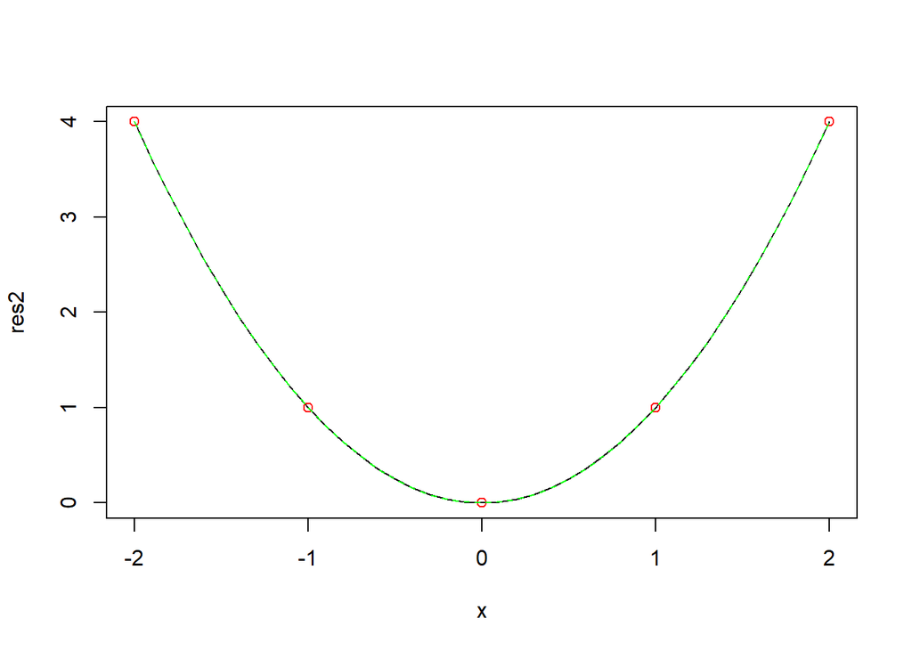

```r
#zname body
xs <- seq(-2,2,by=1)
ys <- xs*xs

#nezname body (x osa)
x<- seq(-2,2,by=0.1)

y<-x^2 #opravdova funkce

A <- vandermonde.matrix(xs, length(xs))   #Vandermodovo matice z hodnot znamych bodu osy X
B <- solve(A,ys)  #interpolacni polynom (koeficienty)

#dosazeni za x do polynomu
res2 <- horner(x,B)

#graf
plot(x,res2, type="l") #interpolace
points(xs,ys, col="red") #zname body
lines(x,y, col="green", lty=2) #opravdova funkce
```

# Lagrangeův interpolační polynom

### Definice

Máme daný soubor n+1 bodů

$$(x_0, y_0),...,(x_i, y_i),...,(x_n, y_n)$$

kde žádná $x_i$ nejsou stejná, interpolační polynom Lagrangeovo tvaru je lineární kombinací

$$P_n(x)=\sum_{i=0}^n L_i(x) y_i$$

Lagrangeova fundamentálních polynomů

$$L_i=\prod_{i=0, i\neq j}^n \frac{x-x_i}{x_j-x_i}$$

### Algoritmus výpočtu:

```r
#xs a ys jsou zname body funkce, x jsou hledane body
lagrangeInterpolation<- function(x, xs, ys)
{
  n <- length(xs)
  sum <- 0
  for(i in 1:n)
  {
    pie <- 1 #pi je 1 pro vypocet dalsiho Li(x)
    for(j in 1:n)
    {
      if(i != j)
      {
        #vypočítáme fundamentální polynom Li(x)
        pie<- pie * (x - xs[j])/(xs[i] - xs[j])
      }
    }
    #přičte se dalsi cast Li(x)*f(xi)
    sum <- sum + ys[i] * pie
  }
  return(sum)
}
```

## Newtonova interpolace

Newtonova interpolace nebo také jako Newtonova metoda poměrných diferencí je interpolační polynom zapsaný ve tvaru:

$$N_n(x) = a_0 + a_1(x-x_0) + a_2(x-x_0)(x-x_1) + ... + a_n(x-x_0)(x-x_1)...(x-x_{n-1})$$

Přičemž k vytvoření polynomu musejí být nalezeny konstanty $a_0$, $a_1,...,a_n$. K nalezení těchto konstant jsou potřeba poměrné diference, které jsou rekursivně generovány, dokud neproběhne $n$ iterací. Začíná se s nultou poměrnou diferencí funkce $f$ vzhledem k $x_i$, což je hodnota $f$ v tomto bodě. Hranaté závorky jsou zavedeny, aby jsme odlišili poměrnou diferenci.

$$f[x_i]=f(x_i)$$

Pak začneme rekursivní volání poměrných diferencí. Na řadě je první poměrná diference k hodnotě $x_i$ a $x_{i+1}$ ve tvaru:

$$f[x_i, x_{i+1}]= \frac{f[x_{i+1}]-f[x_i]} {x_{i+1}-x_i}$$

Následuje druhá poměrná diference:

$$f[x_i, x_{i+1}, x_{i+2}]= \frac{f[x_{i+1}, x_{i+2}]-f[x_i,x_{i+1}]} {x_{i+2}-x_i}$$

a takto pak iterace pokračuje až do $n$té poměrné diference:

$$f[x_0,x_1,...x_n] = \frac{f[x_1,x_2,...,x_n] - f[x_0,x_1,...x_{n-1}]} {x_n-x_0}$$

Interpolační polynom pak se znázorněnými poměrnými diferenci vypadá takto:

$$N_n(x) = f[x_0] + f[x_0,x_1](x-x_0) + f[x_0,x_1,x_2](x-x_0)(x-x_1) + ... + f[x_0,x_1,...,x_n](x-x_0)(x-x_1)...(x-x_{n-1})$$

Pro lepší názornost je níže zobrazen strom výpočtu poměrných diferencí.

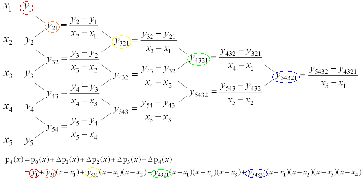

Zdroj obrázku: https://ece.uwaterloo.ca/~dwharder/NumericalAnalysis/05Interpolation/newton/images/p4.colour.png

### Algoritmus výpočtu

```r
divDiff <- function(xs, ys, x)
{
  n <- length(xs)
  q <- matrix(data = 0, n, n)  #q - iniciace matice pomernych diferenci
  q[,1] <- ys
  f <- q[1,1]

  for (i in 2:n)
  {
    fi <- 1
    for (j in i:n)
    {
      q[j,i] <- (q[j,i-1] - q[j-1,i-1]) / (xs[j] - xs[j-i+1])  #spocita diferenci

      if (j==i) #vybere diference do rovnice (diagonala matice)
      {

        for(k in 1:(j-1))
        {
          fi <- fi*(x - xs[k])   #spocte zavorky
        }
        fi <- q[i,j] * fi    #vynasobi s diferenci
      }
    }
      f <- f + fi #prida k celku rovnice
  }
  res <- list(f,q)
  names(res) <- c("y","diff")
  return(res)    #vraci list s interpolaci a matici diferenci
}
```